# Learning Spread and Gather with R Notebooks

I’ve written this lesson to show you two things at once:

1. a clear example of the `gather` and `spread` functions of the `tidyr` package (which we installed as part of the `tidyverse` meta-package), and
2. R Notebooks, an elaboration of the bog-standard R script, which offer enhancements to previewing you work as you go, the ability to glance at your data frames in-place, massively upgraded room for comments and documentation, and ease of sharing your work (or work in-progress) by rendering it to a self-contained webpage you can publish or email (or whatever).

Glance through this page and get ready to open a new project in Rstudio specifically for this demonstration, and we’ll use the code blocks you see below to build your own R Notebook that executes the gather and spread functions shown, and learn how R notebooks generally work. It is up to you if you prefer Notebooks to Scripts for general use.

The Rmd file which generated this page can be found here, but don’t bother with that yet: [(https://github.com/rltillett/bch-709/blob/master/Rnotebooks/gapminder.Rmd)](https://github.com/rltillett/bch-709/blob/master/Rnotebooks/gapminder.Rmd). I’ve also linked it later in this page.

## Initial instructions

1. In Rstudio, click the button with a cube and green + on it to make a new project. name it “gapminder”.
2. Now click the other button with a green + symbol, and choose “R Notebook”.
3. Save the new notebook as “gapminder.Rmd” or something.

The notebook comes pre-loaded with some basic instructions for “what the heck am i supposed to do here?”, a demo of how Notebooks can show off plots, and shortcuts for making **code chunks**, a key difference between a vanilla R script and a Notebook. In an R script, all lines of text are expected to be `R code` unless they begin with the `#` comment symbol. In Notebooks, the sense is inverted: all the text is text, unless it is found inside of an executable *code chunk*.

We’ll interactively explore your new R Notebook and then re-visit this page to learn how to effectively use `gather()` and `spread()`. Oh, and we’re going to use the `gapminder` dataset we first saw in [Greg Martin’s tour of R video](https://youtu.be/ANMuuq502rE).

## Notebooks are great for plotting

Here is an example of what R notebooks can do with plots.

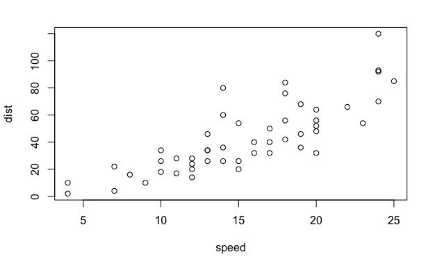

```r
plot(cars)
```

## But they’re also good for documenting complete workflows

### Loading libraries

This chunk is just for recording package install methods (as comments) and for actually loading libraries

```r
# package installs have been commented out.
# if you already have installed, don't re-install for no reason!
# install.packages("tidyverse")
# install.packages("gapminder")
library(gapminder)
library(tidyverse)
```

If you want your notebook to be able to be ran by someone using a vanilla install of R, you would want to un-comment your `install.packages` lines, but then the script will try to download and install the packages every time that chunk of code runs. Kind of wasteful, especially for big and complicated packages. I prefer to include the install commands as comments, **wave a big flag** (like this), and instruct users to install the indicated packages themselves before running the Notebook.

### Importing gapminder into a data frame

Here we make the gapminder table (data frame from the gapminder data/fcn)

```r
gapminder_table <- gapminder
gapminder_table
```

| country | continent | year | lifeExp | pop | gdpPercap |
| --- | --- | --- | --- | --- | --- |
| Afghanistan | Asia | 1952 | 28.80100 | 8425333 | 779.4453 |
| Afghanistan | Asia | 1957 | 30.33200 | 9240934 | 820.8530 |
| Afghanistan | Asia | 1962 | 31.99700 | 10267083 | 853.1007 |
| Afghanistan | Asia | 1967 | 34.02000 | 11537966 | 836.1971 |
| Afghanistan | Asia | 1972 | 36.08800 | 13079460 | 739.9811 |
| Afghanistan | Asia | 1977 | 38.43800 | 14880372 | 786.1134 |
| Afghanistan | Asia | 1982 | 39.85400 | 12881816 | 978.0114 |
| Afghanistan | Asia | 1987 | 40.82200 | 13867957 | 852.3959 |
| Afghanistan | Asia | 1992 | 41.67400 | 16317921 | 649.3414 |
| Afghanistan | Asia | 1997 | 41.76300 | 22227415 | 635.3414 |

[output cut: 990 more lines]

```r
summary(gapminder_table)
```

```
        country        continent        year         lifeExp
 Afghanistan:  12   Africa  :624   Min.   :1952   Min.   :23.60
 Albania    :  12   Americas:300   1st Qu.:1966   1st Qu.:48.20
 Algeria    :  12   Asia    :396   Median :1980   Median :60.71
 Angola     :  12   Europe  :360   Mean   :1980   Mean   :59.47
 Argentina  :  12   Oceania : 24   3rd Qu.:1993   3rd Qu.:70.85
 Australia  :  12                  Max.   :2007   Max.   :82.60
 (Other)    :1632
      pop              gdpPercap
 Min.   :6.001e+04   Min.   :   241.2
 1st Qu.:2.794e+06   1st Qu.:  1202.1
 Median :7.024e+06   Median :  3531.8
 Mean   :2.960e+07   Mean   :  7215.3
 3rd Qu.:1.959e+07   3rd Qu.:  9325.5
 Max.   :1.319e+09   Max.   :113523.1
```

### Spread data by year

Now we spread the data for 2 countries, each year gets a column

```r
year_spread <- gapminder_table %>%
  filter(year>1951) %>%
  filter(country== "Afghanistan" |
           country=="Ireland") %>%
  select(country,year,lifeExp) %>%
  spread(year, lifeExp)
year_spread
```

| country | 1952 | 1957 | 1962 | 1967 | 1972 | 1977 | 1982 | 1987 | 1992 | 1997 | 2002 | 2007 |
| --- | --- | --- | --- | --- | --- | --- | --- | --- | --- | --- | --- | --- |
| Afghanistan | 28.801 | 30.332 | 31.997 | 34.02 | 36.088 | 38.438 | 39.854 | 40.822 | 41.674 | 41.763 | 42.129 | 43.828 |
| Ireland | 66.910 | 68.900 | 70.290 | 71.08 | 71.280 | 72.030 | 73.100 | 74.360 | 75.467 | 76.122 | 77.783 | 78.885 |

### Gather years back to tidy format

and now we easily gather them back into a *tidy* format, starting from the `year_spread` data frame

```r
year_gather <- year_spread %>%
  gather(year, lifeExp, "1952":"2007")
year_gather
```

| country | year | lifeExp |
| --- | --- | --- |
| Afghanistan | 1952 | 28.801 |
| Ireland | 1952 | 66.910 |
| Afghanistan | 1957 | 30.332 |
| Ireland | 1957 | 68.900 |
| Afghanistan | 1962 | 31.997 |
| Ireland | 1962 | 70.290 |
| Afghanistan | 1967 | 34.020 |
| Ireland | 1967 | 71.080 |
| Afghanistan | 1972 | 36.088 |
| Ireland | 1972 | 71.280 |

[output cut: 14 more lines]

## Making your notebook look nice with Markdown

This webpage was 100% generated from an R Markdown **Rmd** file, [specifically, this Rmd file.](https://github.com/rltillett/bch-709/blob/master/Rnotebooks/gapminder.Rmd) As you use the code sections on this webpage to construct your own R Markdown file for gathering and spreading operations, your Rmd file and the html file that it generates on Run+Save will contain the “meat and potatoes” found in this page.

To go further, and to create nice formatting for the free text in between R chunks, you’ll want to use Markdown syntax to format the text not-inside the R chunks. With Markdown syntax, you can very easily do things like

- making lists
- mark text as **bold**,
- or *italic*
- set section headings of varying size (lines starting with # symbols. `#` for H1, `##` is H2, and so forth). Sorry, I can’t show this in this bulleted list.
- make section breaks with 3 dashes `-` *but be careful to place an empty line after these breaks. The Rmd to html converter in Rstudio is hyper-strict about breaks, and will glitch out subsequent sections if you don’t have an empty line after things like section breaks (and maybe lists).*
- inline code delimiters (for function names, maybe?) by wrapping text between backticks `like this`

You can find a pretty useful Markdown syntax primer at Github, for Github’s own version of Markdown [here](https://github.com/adam-p/markdown-here/wiki/Markdown-Cheatsheet). Not all of the features have parity in R Markdown, but most do. And, as noted above, R Markdown can by hypersensitive about how you should leave blank lines around syntax features that involve vertical space on the page (section breaks and probably others too).

Note that all or most of these Markdown syntax text formattings are also available to you when writing text files and putting them up on [github](https://github.com) and in the chat client I’ve been asking you to use gitter.im